# HW10

Alexandra Gibbons

2022-11-04

## 9E1

Only (3) is a requirement of the simple Metropolis algorithm.

## 9E2

In the Metropolis algorithm,there is an equal chance of proposing a jump in any given direction. With Gibbs sampling, there are adaptive proposals with asymmetric probabilities, which allows posterior estimation from fewer samples than possible with the Metropolis algorithm. These adaptive proposals are based on information from conjugate pairs (combination of prior distribution and likelihood), which can be solved to find the posterior distribution of individual parameters. The major limitation to Gibbs sampling (this is also a downside of the Metropolis algorithm) is that in models with many parameters, it will often get stuck in regions of high correlation between two or more parameters (concentration of measure) and thus will be ineffective at exploring the whole posterior distribution and identifying the region of the posterior distribution with the most probability mass.

## 9E3

Hamiltonian Monte Carlo can’t handle non-continuous (discrete) parameters because the simulated particle needs a continuous surface to “glide” over while sampling.

## 9E4

The effective number of samples takes autocorrelation among sequential samples into account (actual number of samples does not), and gives an estimate of the length that your Markov chain would be had there been no autocorrelation. If sequential samples are anti-correlated, n_eff can be larger than the actual number of samples.

## 9E5

Rhat should approach 1 (from above) when a chain is sampling the posterior distribution correctly.

## 9E6

“Sketch a good trace plot for a Markov chain,one that is effectively sampling from the posterior distribution. What is good about its shape? Then sketch a trace plot for a malfunctioning Markov chain. What about its shape indicates malfunction?”

```r
y <- rnorm( 100 , mean=100 , sd=1 )
e6a <- ulam(
    alist(
        y ~ dnorm( mu , sigma ) ,
        mu <- a1 + a2 ,
        a1 ~ dnorm( 0 , 1000 ),
        a2 ~ dnorm( 0 , 1000 ),
        sigma ~ dexp( 1 )
    ) , data=list(y=y) , chains=3, cores=3 )
```

[output not shown]

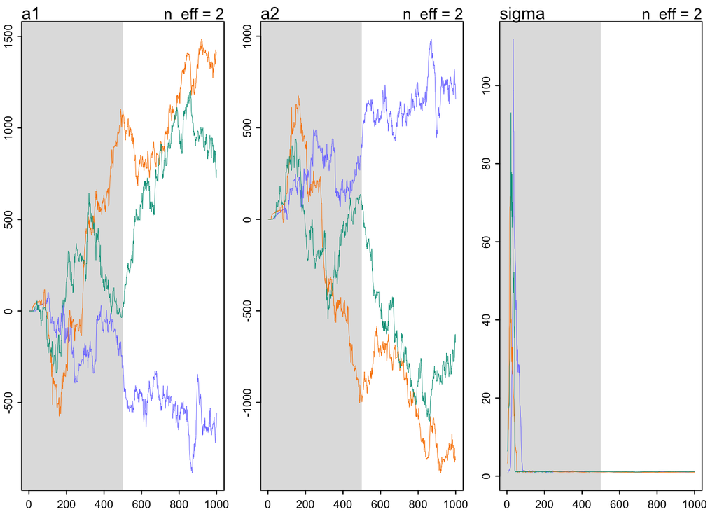

```r
traceplot(e6a)
```

```r
e6b <- ulam(
    alist(
        y ~ dnorm( mu , sigma ) ,
        mu <- a1 + a2 ,
        a1 ~ dnorm( 50 , 10 ),
        a2 ~ dnorm( 50, 10 ),
        sigma ~ dexp( 1 )
    ) , data=list(y=y) , chains=3, cores=3 )
```

[output not shown]

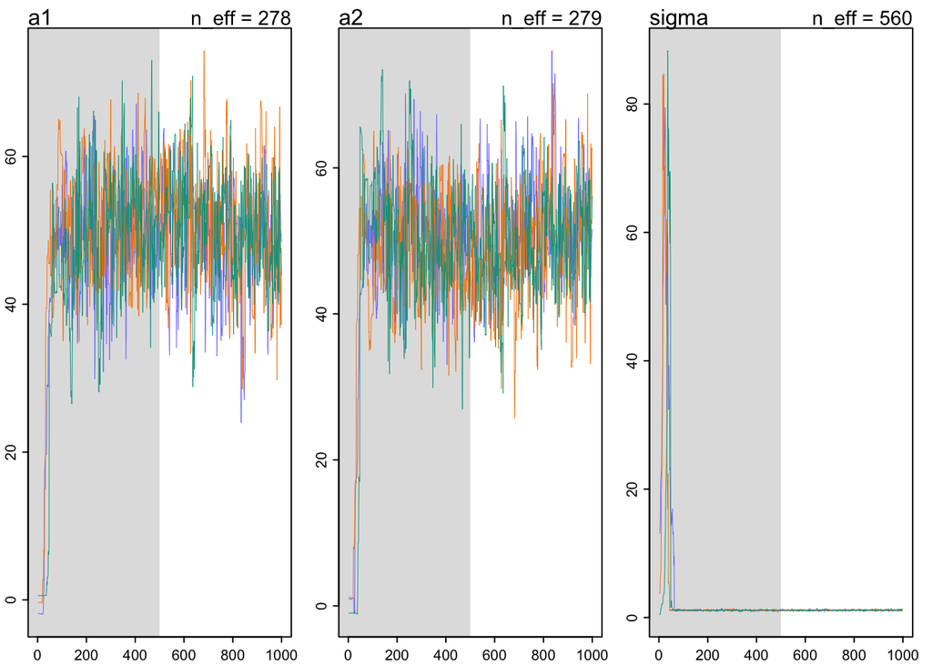

```r
traceplot(e6b)
```

The first set of trace plots are horrible, especially for a1 and a2; they are not stationary, do not have good mixing, and do not converge. The second set of trace plots look healthy, like fluffy caterpillars (and satisfy stationarity, good mixing, and convergence requirements).

## 9E7

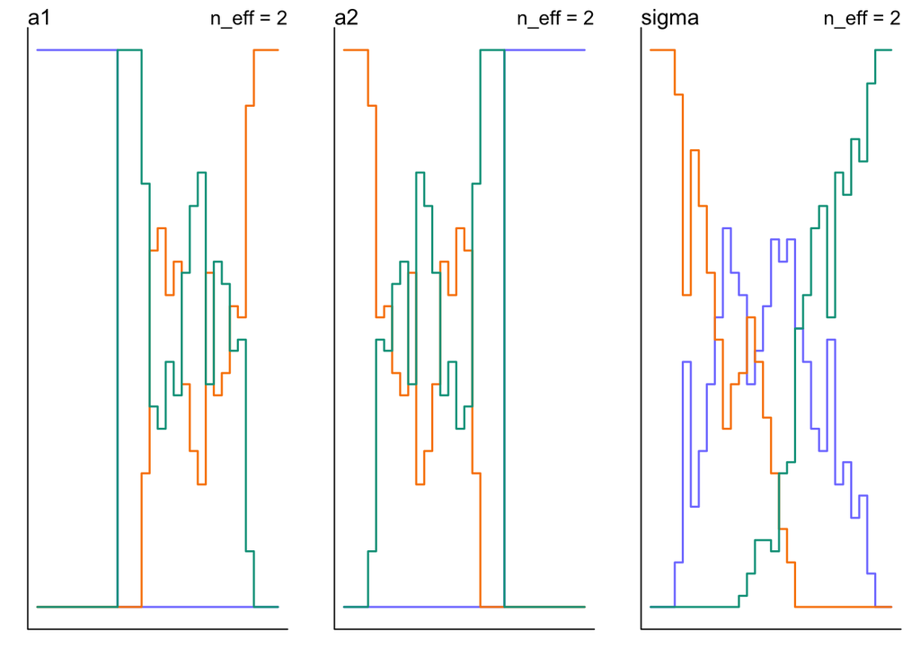

```r
trankplot(e6a)
```

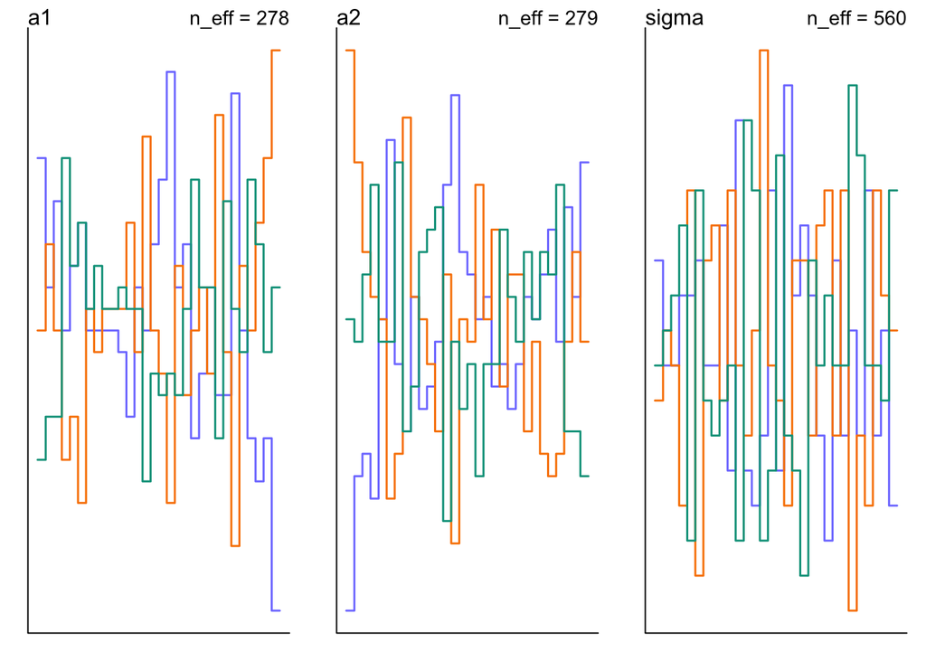

```r
trankplot(e6b)
```

This first set of trank plots is bad, again especially for a1 and a2; these histograms are not staying in the same range and there isn’t a ton of overlap. The second set of trank plots is good, lots of overlap!

## 9M1

```r
data(rugged)
d <- rugged
dd <- d %>%
  drop_na(rgdppc_2000) %>%
  mutate(log_gdp=log(rgdppc_2000)) %>%
  mutate(log_gdp_std = log_gdp / mean(log_gdp),
         rugged_std = rugged / max(rugged),
         cid = ifelse(cont_africa == 1, "1", "2")) %>%
  mutate(rugged_std_c = rugged_std - mean(rugged_std))

dat_slim <- dd %>%
  mutate(cid = as.integer(cid)) %>%
  dplyr::select(log_gdp_std, rugged_std, cid, rugged_std_c)

str(dat_slim)
```

```
## 'data.frame':    170 obs. of  4 variables:
##  $ log_gdp_std : num  0.88 0.965 1.166 1.104 0.915 ...
##  $ rugged_std  : num  0.138 0.553 0.124 0.125 0.433 ...
##  $ cid         : int  1 2 2 2 2 2 2 2 2 1 ...
##  $ rugged_std_c: num  -0.0766 0.3376 -0.091 -0.09 0.2184 ...
```

```r
#first do original model
m1a <- ulam(
    alist(log_gdp_std ~ dnorm( mu , sigma ),
        mu <- a[cid] + b[cid]*( rugged_std - 0.215 ),
        a[cid] ~ dnorm( 1 , 0.1 ),
        b[cid] ~ dnorm( 0 , 0.3 ),
        sigma ~ dexp( 1 )),
    data=dat_slim , chains=4, cores=4 )
```

[output not shown]

[output not shown]

[output not shown]

[output not shown]

[output not shown]

```
## Chain 1
```

[output not shown]

[output not shown]

[output not shown]

[output not shown]

[output not shown]

```
## Chain 2
```

[output not shown]

[output not shown]

[output not shown]

[output not shown]

[output not shown]

```
## Chain 3
```

[output not shown]

```r
precis(m1a, depth=2)
```

```
##             mean          sd        5.5%       94.5%    n_eff     Rhat4
## a[1]   0.8869890 0.015882527  0.86144131  0.91203561 2721.467 0.9987569
## a[2]   1.0503787 0.009855534  1.03454780  1.06560550 3005.087 0.9995280
## b[1]   0.1358661 0.075110315  0.01529687  0.25719747 2720.565 0.9989611
## b[2]  -0.1427917 0.055396817 -0.23492248 -0.05619196 2993.768 1.0003323
## sigma  0.1114344 0.006127912  0.10222283  0.12121027 3531.498 0.9986909
```

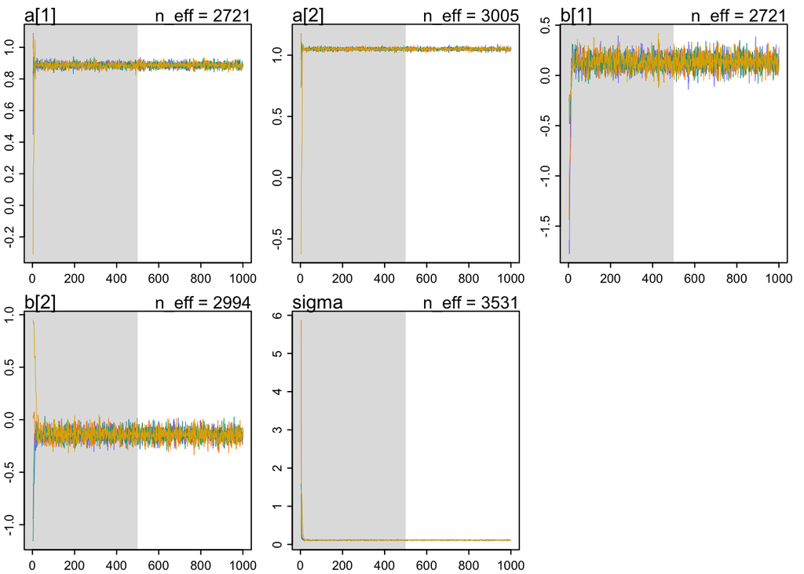

```r
traceplot(m1a)
trankplot(m1a)
```

```r
# w/ new prior
m1b <- ulam(
    alist(log_gdp_std ~ dnorm( mu , sigma ),
        mu <- a[cid] + b[cid]*( rugged_std - 0.215 ),
        a[cid] ~ dnorm( 1 , 0.1 ),
        b[cid] ~ dnorm( 0 , 0.3 ),
        sigma ~ dunif(0,  1 )),
    data=dat_slim , chains=4, cores=4)
```

[output not shown]

[output not shown]

[output not shown]

[output not shown]

[output not shown]

```
## Chain 3
```

[output not shown]

```r
precis(m1b, depth=2)
```

```
##             mean          sd       5.5%       94.5%    n_eff     Rhat4
## a[1]   0.8863650 0.016371681  0.8606814  0.91249233 2662.524 0.9999069
## a[2]   1.0504900 0.010346155  1.0333739  1.06678110 2526.025 1.0017441
## b[1]   0.1311641 0.075153777  0.0081194  0.24764335 2421.828 1.0003554
## b[2]  -0.1410080 0.055635188 -0.2292559 -0.05168901 2678.747 0.9988154
## sigma  0.1116778 0.006201666  0.1020653  0.12209632 2411.176 0.9996788
```

[figure not shown]

```r
traceplot(m1b)
```

[figure not shown]

```r
trankplot(m1b)
```

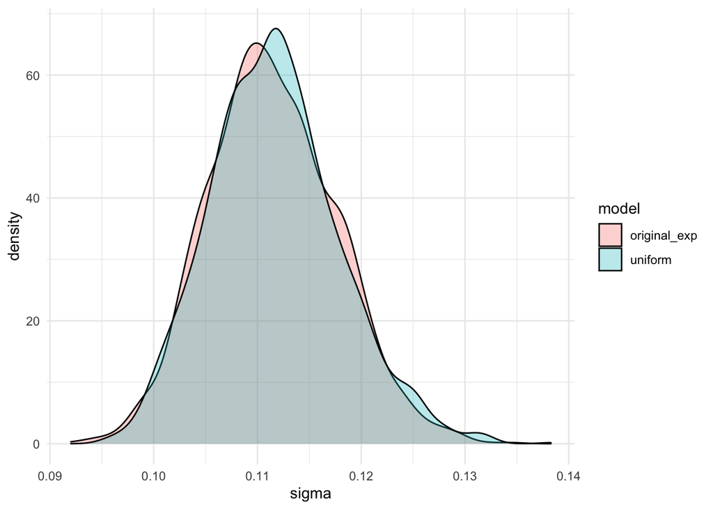

```r
# let's try to compare the posteriors for sigma
m1a_post <- extract.samples(m1a) %>% pluck("sigma")
m1b_post <- extract.samples(m1b) %>% pluck("sigma")
compare <- tibble(original_exp = m1a_post,
                  uniform = m1b_post) %>%
  pivot_longer(names_to="model",
               values_to="sigma",
               cols=everything())

compare %>% ggplot(aes(x=sigma, fill=model)) +
  geom_density(alpha=.3) + theme_minimal()
```

Not seeing huge differences, the data seems to have mostly overwhelmed the priors, though the mode and shapes of the posterior distributions of sigma are slightly different.

## 9M2

```r
m1c <- ulam(
    alist(log_gdp_std ~ dnorm( mu , sigma ),
        mu <- a[cid] + b[cid]*( rugged_std - 0.215 ),
        a[cid] ~ dnorm( 1 , 0.1 ),
        b[cid] ~ dexp( 0.3 ),
        sigma ~ dexp( 1 )),
    data=dat_slim , chains=4, cores=4 )
```

[output not shown]

[output not shown]

[output not shown]

[output not shown]

[output not shown]

```
## Chain 1
```

[output not shown]

[output not shown]

[output not shown]

[output not shown]

[output not shown]

```
## Chain 2
```

[output not shown]

[output not shown]

[output not shown]

[output not shown]

[output not shown]

```
## Chain 3
```

[output not shown]

[output not shown]

[output not shown]

[output not shown]

[output not shown]

```
## Chain 4
```

[output not shown]

```r
precis(m1c, depth=2)
```

```
##             mean          sd        5.5%     94.5%    n_eff     Rhat4
## a[1]  0.88656228 0.016286412 0.860948780 0.9126326 1583.847 0.9995564
## a[2]  1.04831811 0.010258985 1.031769450 1.0648822 1957.022 0.9992384
## b[1]  0.14857555 0.070219374 0.041720767 0.2666245 1389.912 0.9998928
## b[2]  0.01848481 0.017286354 0.001041636 0.0512470 1895.122 0.9994243
## sigma 0.11392816 0.006085685 0.104621505 0.1237220 1573.489 0.9992653
```

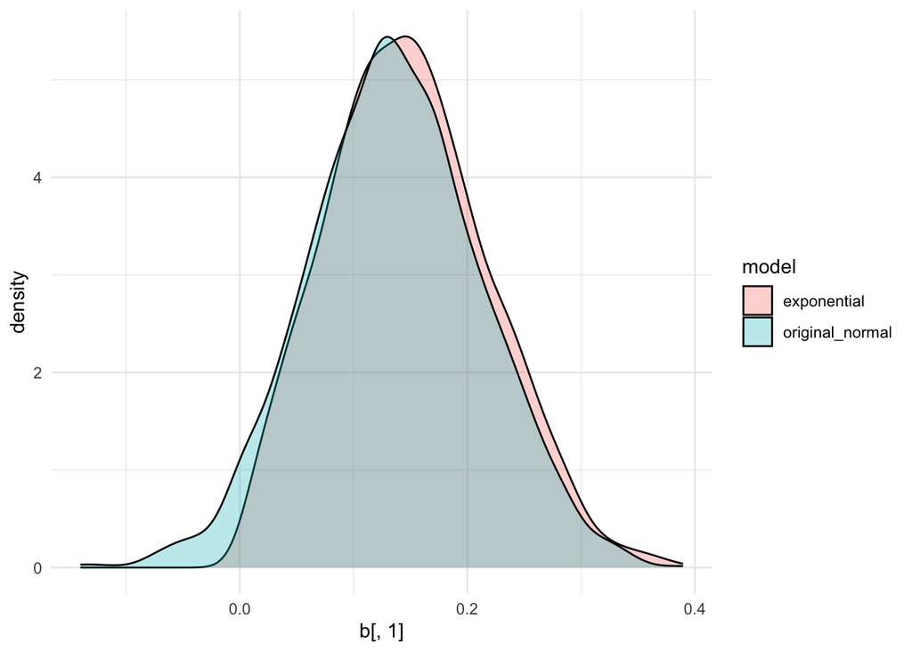

```r
m1a_post2 <- extract.samples(m1a) %>% pluck("b")
m1c_post <- extract.samples(m1c) %>% pluck("b")

compare2 <- tibble(original_normal = m1a_post2,
                  exponential = m1c_post) %>%
  pivot_longer(names_to="model",
               values_to="b",
               cols=everything())

compare2 %>% ggplot(aes(x=b[,1], fill=model)) +
  geom_density(alpha=.3) + theme_minimal()
```

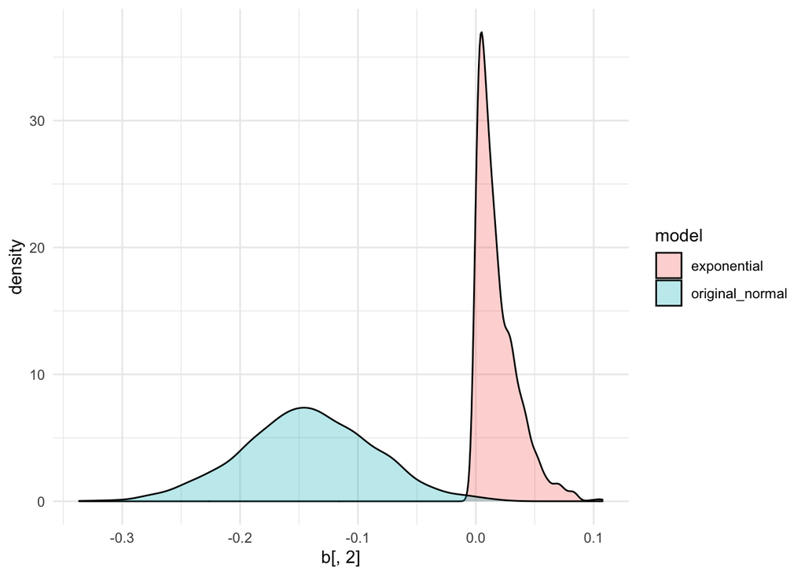

```r
compare2 %>% ggplot(aes(x=b[,2], fill=model)) +
  geom_density(alpha=.3) + theme_minimal()
```

Based on the precis output, the posterior distribution of b (assoc. between ruggedness and log gdp) for African nations is relatively similar across both models, though the shapes are slightly different. However, the posterior distribution of b for the non-African nations is very different, as can also be seen in the plot above. This is because we constrained this slope to be positive, when in reality it should be negative. Also notice that the posterior distribution is much more concentrated with the exponential prior compared to the posterior distribution with the normal prior, which makes sense because our prior is also more concentrated.